# RNA-seq Differential Expression and WGCNA Report

DESeq2, enrichment, module preservation, and hub-gene summary

# 1 Executive Summary

This report summarizes the RNA-seq analysis pipeline for Breast invasive carcinoma (BRCA). The analysis compares tumor samples against normal samples, then uses WGCNA to find co-expression modules, annotate those modules, test preservation, and nominate hub-gene candidates.

In simple terms, the report follows this flow:

1. Differential expression asks which genes change between tumor and normal.
2. Enrichment asks what biological processes those changed genes represent.
3. WGCNA groups genes into modules that move together across samples.
4. Module annotation gives each module a biological label.
5. Preservation checks whether tumor modules are also present in normal tissue.
6. Hub-gene ranking finds central genes inside important modules.

| Metric | Value |
| --- | --- |
| Samples | 1207 |
| Genes tested for DE | 18158 |
| Significant DE genes | 4823 |
| WGCNA genes assigned to modules | 5000 |
| Non-grey WGCNA modules | 12 |
| Modules with annotation rows | 12 |
| Modules with preservation calls | 14 |
| Ranked hub rows | 256 |
| Priority hub rows | 188 |

# 2 Differential Expression

The DESeq2 step estimates how much each gene changes between tumor and normal. `log2FoldChange` is the size of the change; positive values mean higher in tumor, and negative values mean lower in tumor. `padj` is the multiple-testing corrected p-value.

| Direction | Genes |
| --- | --- |
| Up-regulated | 2854 |
| Down-regulated | 1969 |

Top significant DE genes

| gene_symbol | gene_id | log2FoldChange | padj |
| --- | --- | --- | --- |
| COL10A1 | ENSG00000123500.9 | 7.09 | <1e-300 |
| MMP11 | ENSG00000099953.9 | 6.26 | <1e-300 |
| MYOM1 | ENSG00000101605.12 | -4.78 | <1e-300 |
| GPAM | ENSG00000119927.13 | -4.45 | <1e-300 |
| GOLGA8J | ENSG00000179938.12 | -1.83 | <1e-300 |
| NEK2 | ENSG00000117650.12 | 4.22 | 1.40e-307 |
| MRAP | ENSG00000170262.12 | -2.68 | 3.61e-285 |
| FHL1 | ENSG00000022267.16 | -5.01 | 2.74e-276 |
| TNS1 | ENSG00000079308.16 | -3.12 | 3.14e-275 |
| COL11A1 | ENSG00000060718.20 | 6.14 | 1.06e-260 |
| LYVE1 | ENSG00000133800.8 | -5.02 | 2.54e-255 |
| KIF4A | ENSG00000090889.11 | 3.82 | 8.35e-250 |

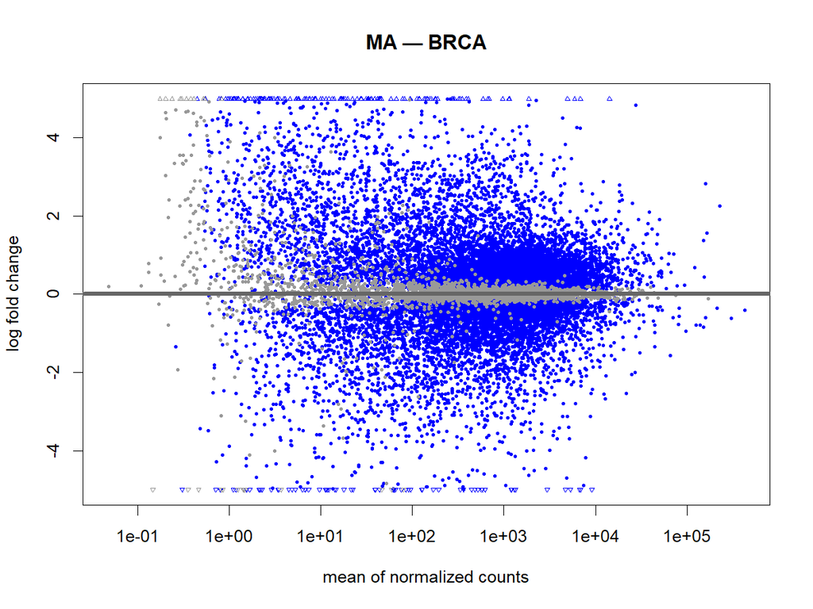

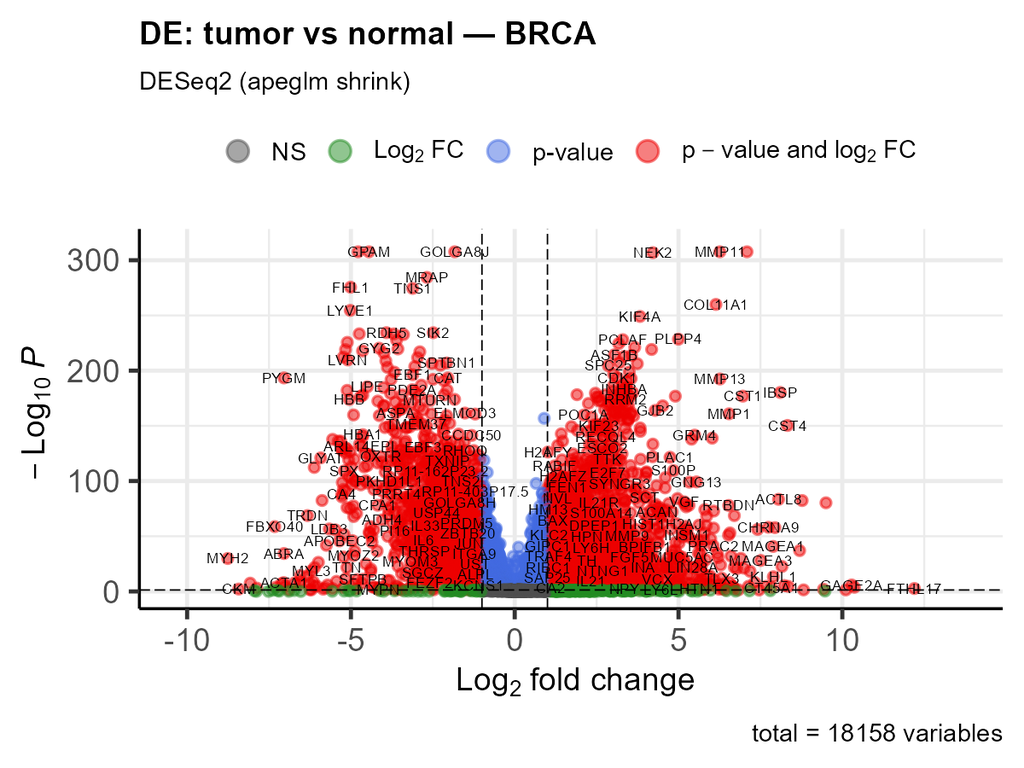

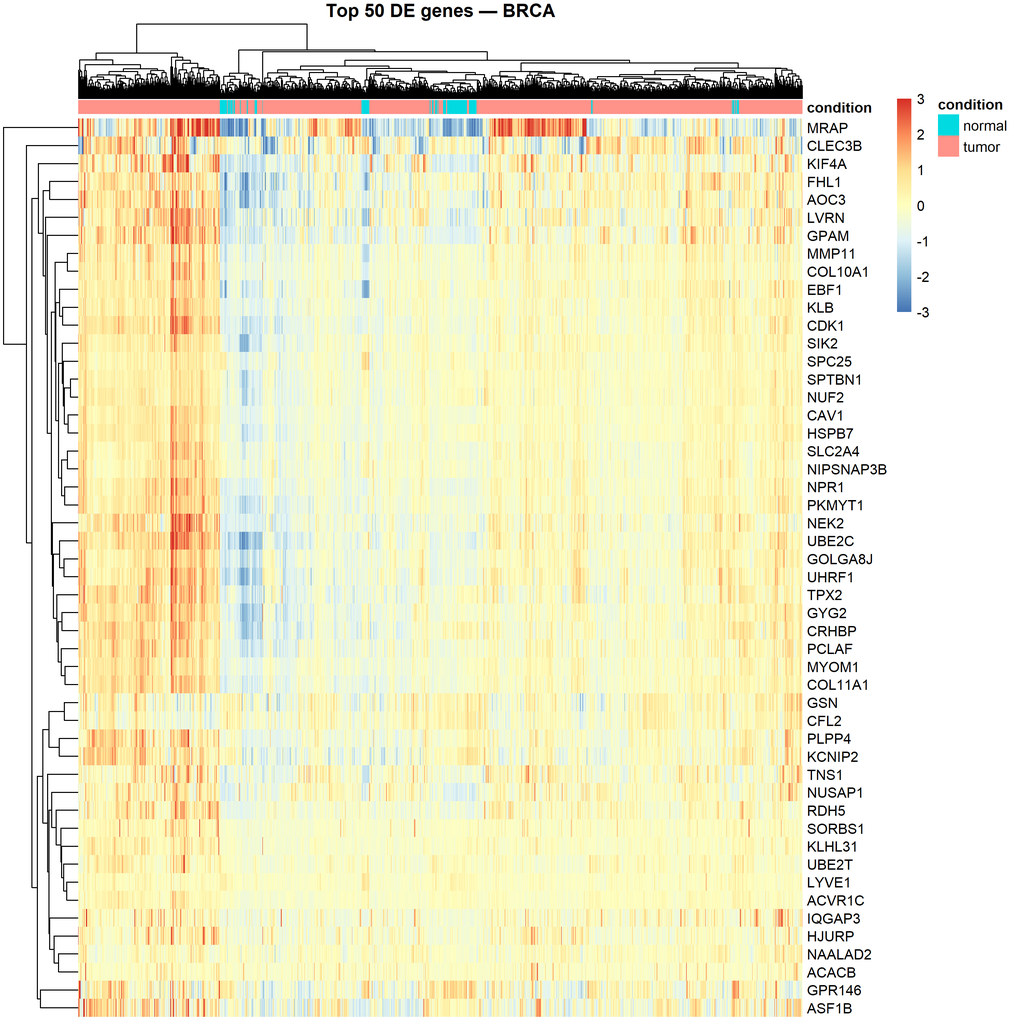

# 3 Functional Enrichment

Over-representation analysis tests the significant up- and down-regulated gene lists. GSEA uses the full ranked gene list, so it can detect biology spread across many genes even when individual genes do not pass a hard cutoff.

| Result | Rows |
| --- | --- |
| GO ORA rows | 1231 |
| KEGG ORA rows | 45 |
| GO GSEA rows | 792 |
| KEGG GSEA rows | 58 |

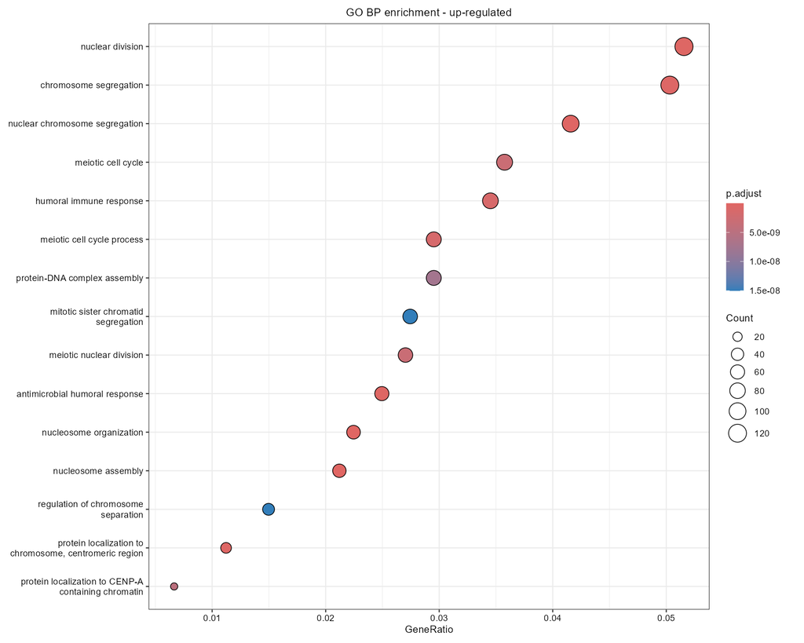

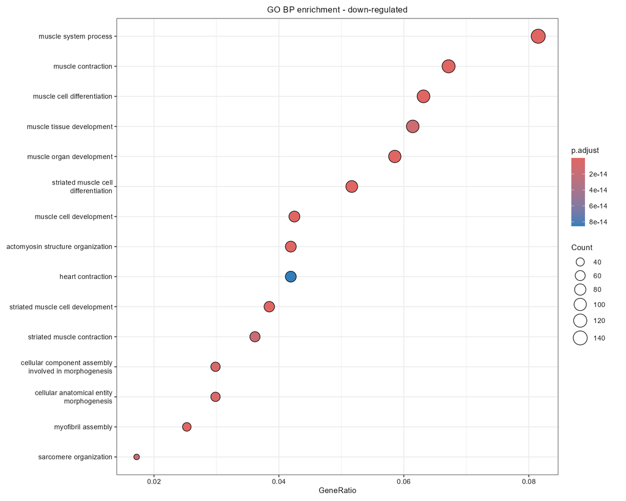

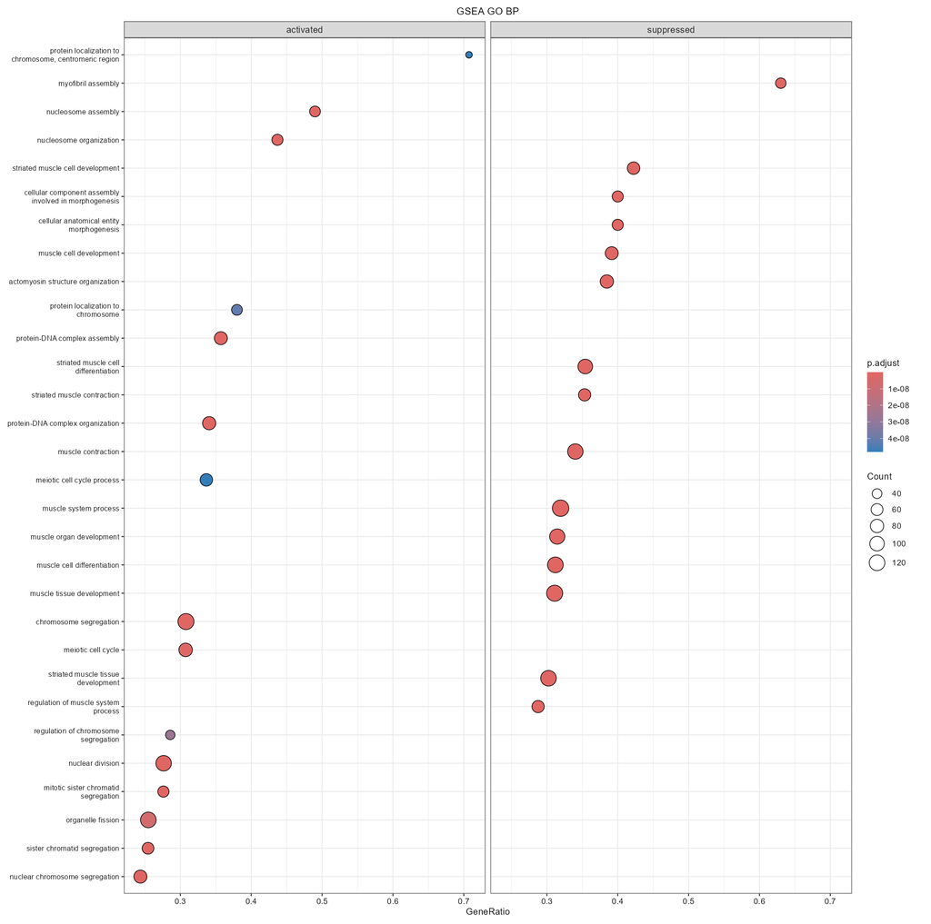

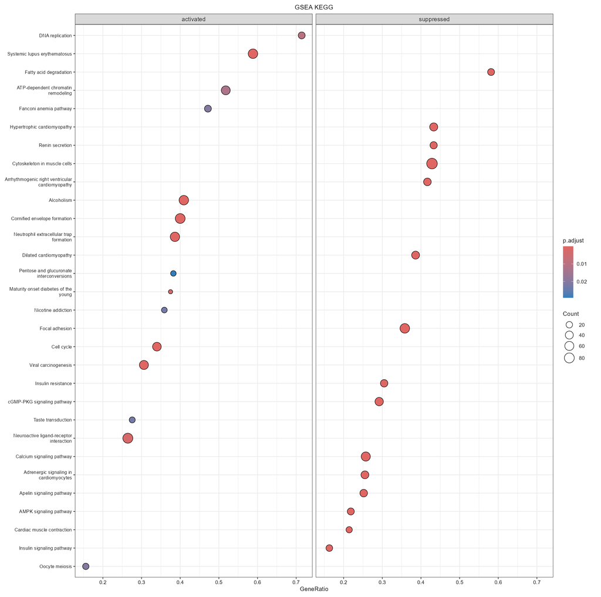

# 4 WGCNA Co-expression Network

WGCNA groups genes into modules based on similar expression patterns. A module is a color label, not a biological label by itself. The biological meaning comes from module-trait correlations and enrichment results.

Largest WGCNA modules

| Module | Genes |
| --- | --- |
| turquoise | 1768 |
| grey | 727 |
| brown | 708 |
| salmon | 437 |
| blue | 436 |
| red | 230 |
| black | 221 |
| pink | 115 |
| magenta | 89 |
| purple | 80 |
| greenyellow | 75 |
| tan | 65 |
| cyan | 49 |

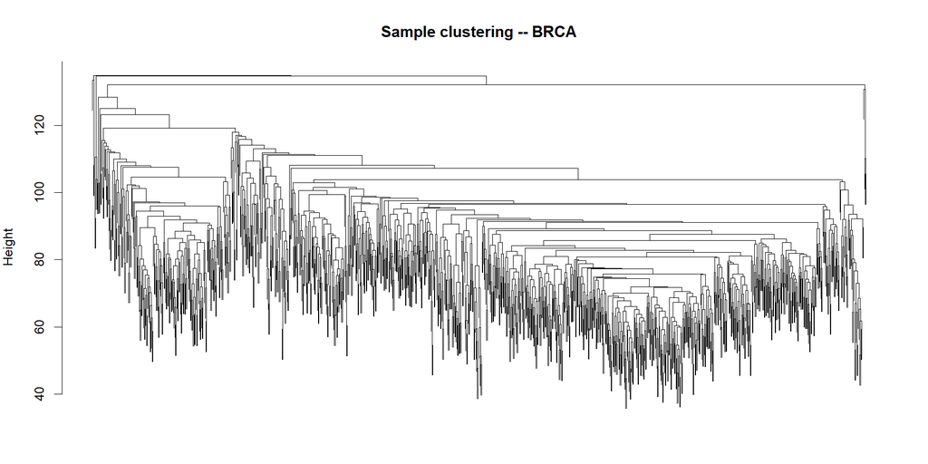

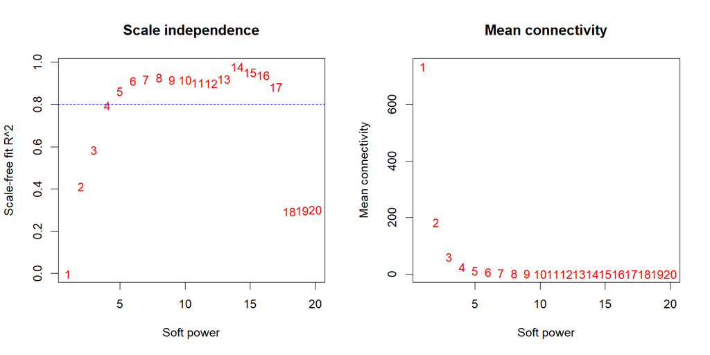

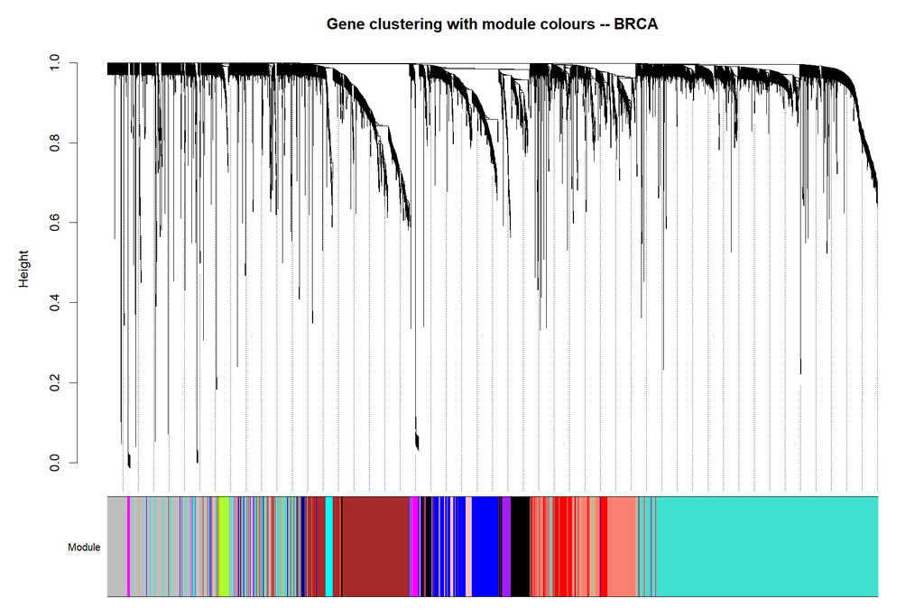

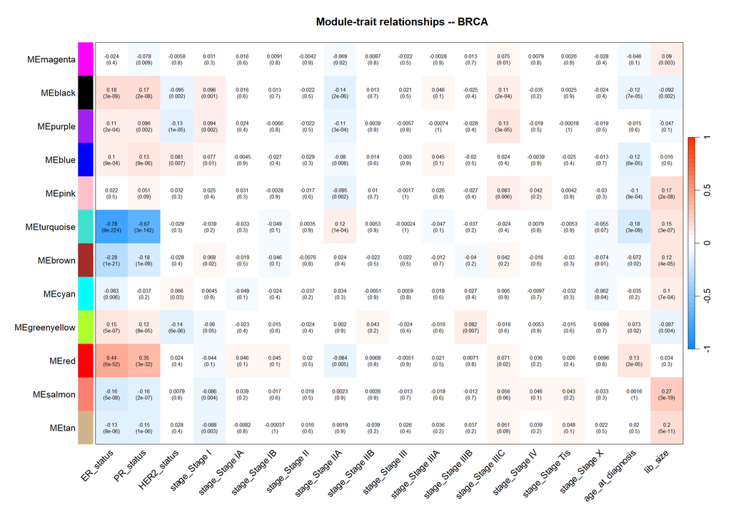

# 5 Module Annotation

This section translates color modules into biological themes. The `best_padj` column is the strongest adjusted p-value among the top GO terms for that module.

Module annotation summary

| module | size | top_term_1 | top_term_2 | top_term_3 | best_padj |
| --- | --- | --- | --- | --- | --- |
| salmon | 423 | cytoplasmic translation | translation | ribonucleoprotein complex biogenesis | 1.09e-22 |
| cyan | 49 | defense response to virus | response to virus | defense response to other organism | 1.05e-40 |
| pink | 114 | collagen metabolic process | extracellular matrix organization | external encapsulating structure organization | 2.28e-03 |
| red | 224 |  |  |  |  |
| turquoise | 1757 | chromosome segregation | nuclear chromosome segregation | mitotic sister chromatid segregation | 1.08e-11 |
| brown | 695 | lymphocyte activation | leukocyte activation | adaptive immune response | 9.03e-74 |
| blue | 436 | extracellular matrix organization | external encapsulating structure organization | extracellular structure organization | 1.89e-24 |
| purple | 80 | lipid metabolic process | carboxylic acid metabolic process | regulation of lipid metabolic process | 9.10e-06 |
| magenta | 89 | homophilic cell adhesion via plasma membrane adhesion molecules | cell-cell adhesion via plasma-membrane adhesion molecules | cell-cell adhesion | 1.40e-47 |
| greenyellow | 75 | chemical synaptic transmission | anterograde trans-synaptic signaling | trans-synaptic signaling | 3.26e-11 |
| tan | 64 | protein-RNA complex assembly | protein-RNA complex organization | ribonucleoprotein complex biogenesis | 2.19e-02 |
| black | 218 | vasculature development | blood vessel development | angiogenesis | 3.95e-12 |

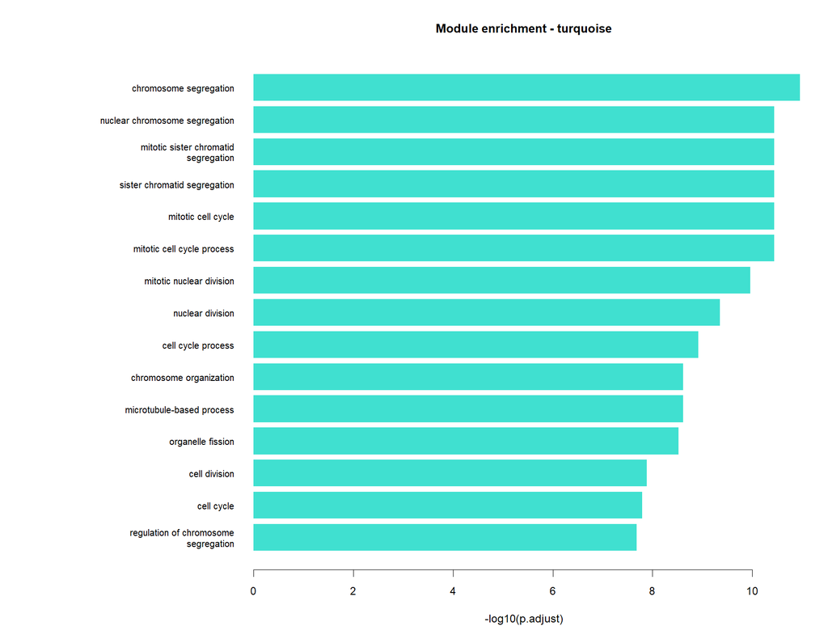

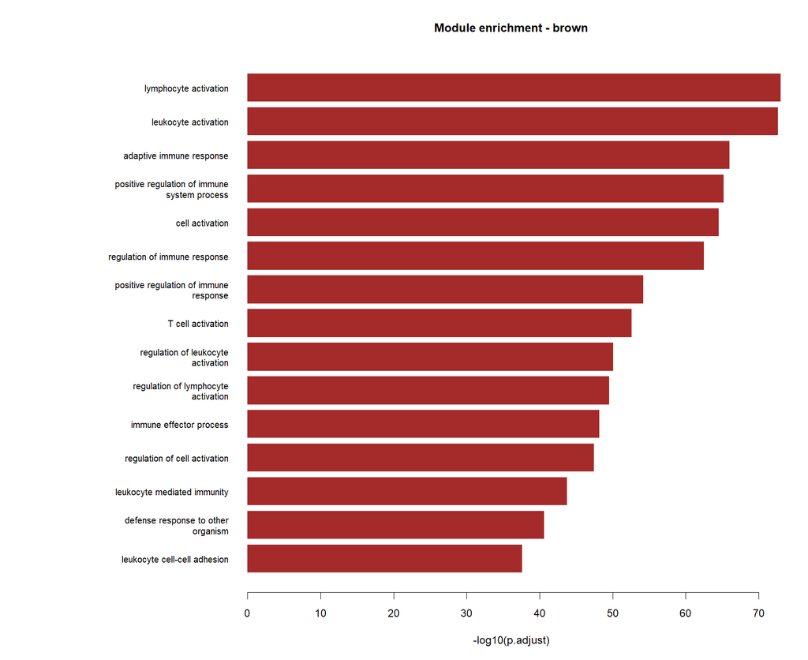

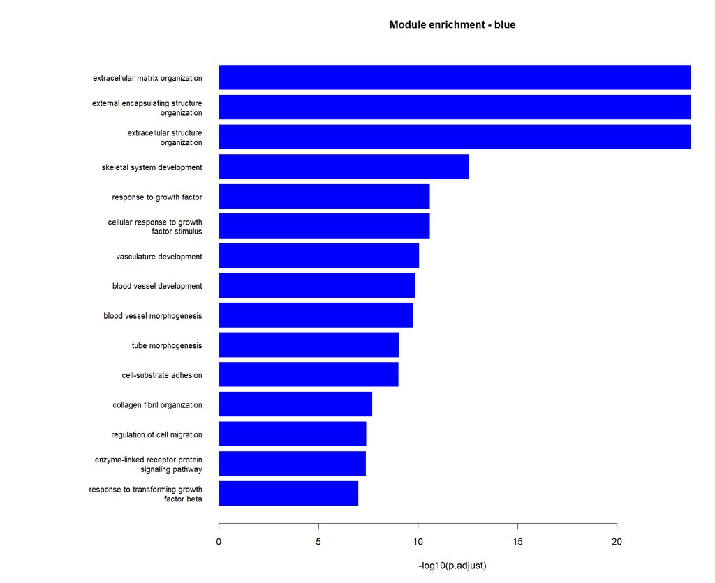

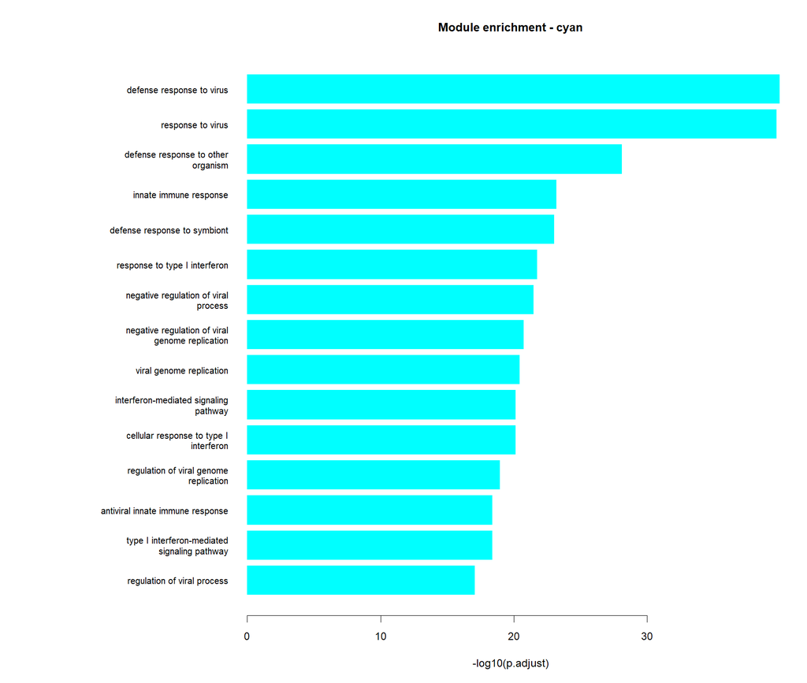

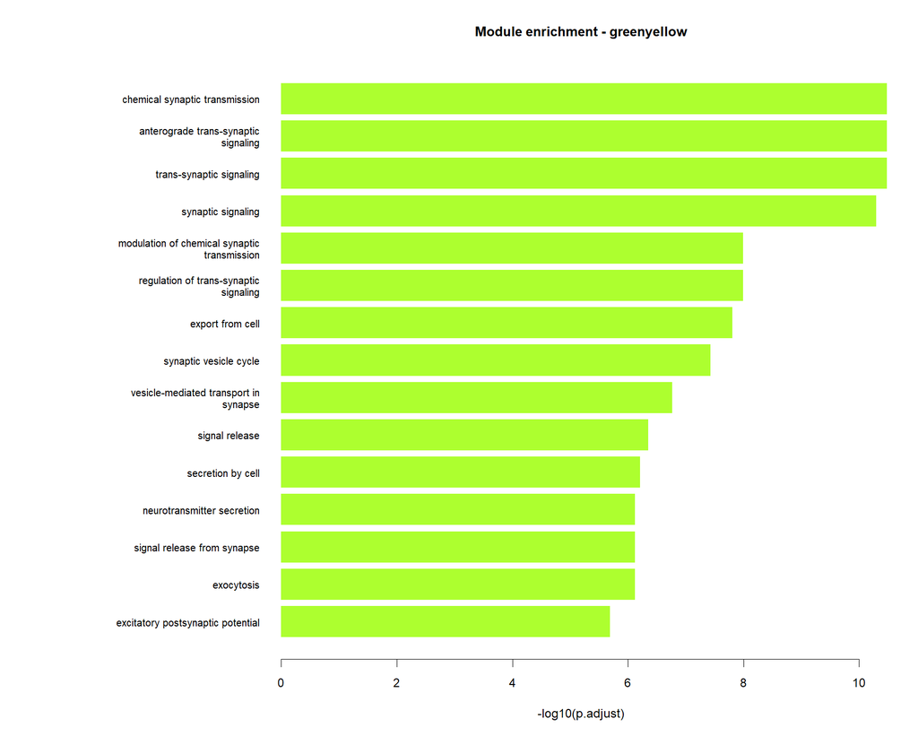

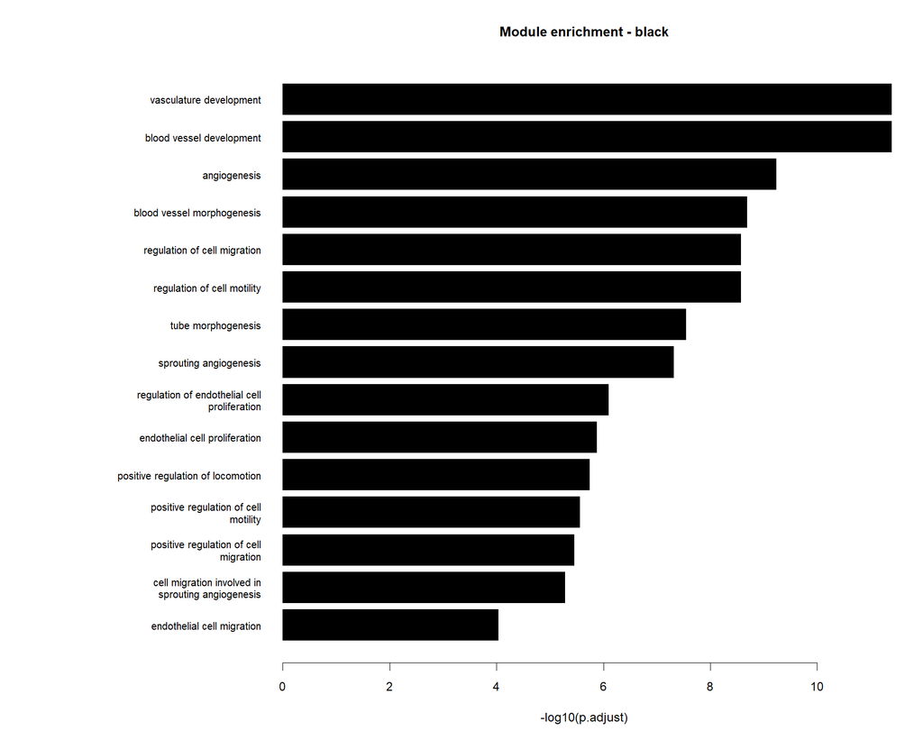

# 6 Module Preservation

Module preservation compares the tumor network against normal samples. A high Z-summary means the module structure is preserved in normal tissue. A low Z-summary suggests tumor-specific network rewiring.

Module preservation calls

| module | moduleSize | Zsummary | medianRank | class |
| --- | --- | --- | --- | --- |
| brown | 708 | 59.08 | NA | preserved |
| blue | 436 | 37.39 | NA | preserved |
| salmon | 437 | 35.22 | NA | preserved |
| black | 221 | 26.56 | NA | preserved |
| pink | 115 | 24.73 | NA | preserved |
| cyan | 49 | 24.45 | NA | preserved |
| purple | 80 | 23.27 | NA | preserved |
| tan | 65 | 22.16 | NA | preserved |
| red | 230 | 20.00 | NA | preserved |
| turquoise | 1768 | 17.52 | NA | preserved |
| magenta | 89 | 14.34 | NA | preserved |
| greenyellow | 75 | 8.52 | NA | preserved |
| all_modules | 5000 | 4.48 | NA | moderate |
| grey | 727 | -0.43 | NA | not_preserved |

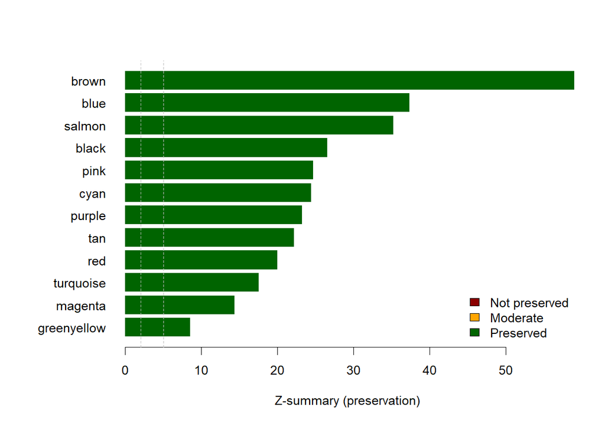

# 7 Hub-gene Candidates

Hub genes are genes with high module membership (`kME`) inside their own module. The priority table keeps modules that are trait-associated, not preserved, or strongly enriched.

Priority hub rows by module

| Module | Priority reason | Hub rows |
| --- | --- | --- |
| black | enriched | 25 |
| blue | enriched | 25 |
| brown | enriched | 25 |
| cyan | enriched | 23 |
| greenyellow | enriched | 9 |
| magenta | enriched | 22 |
| red | trait | 13 |
| salmon | enriched | 25 |
| turquoise | trait;enriched | 21 |

First 30 priority hub-gene rows

| gene_symbol | module | kME | rank_in_module | log2FoldChange | padj | is_DE | best_trait | trait_cor | preservation_class | enrichment_best_padj | priority_reason |
| --- | --- | --- | --- | --- | --- | --- | --- | --- | --- | --- | --- |
| JAM2 | black | 0.90 | 1 | -2.08 | 5.23e-106 | TRUE | ER_status | 0.178 | preserved | 3.95e-12 | enriched |
| LHFP | black | 0.90 | 2 | -2.06 | 4.79e-120 | TRUE | ER_status | 0.178 | preserved | 3.95e-12 | enriched |
| S1PR1 | black | 0.89 | 3 | -2.04 | 6.83e-91 | TRUE | ER_status | 0.178 | preserved | 3.95e-12 | enriched |
| ABCA8 | black | 0.87 | 4 | -3.93 | 4.55e-115 | TRUE | ER_status | 0.178 | preserved | 3.95e-12 | enriched |
| PREX2 | black | 0.87 | 5 | -2.38 | 5.40e-99 | TRUE | ER_status | 0.178 | preserved | 3.95e-12 | enriched |
| IGF1 | black | 0.87 | 6 | -2.30 | 2.28e-55 | TRUE | ER_status | 0.178 | preserved | 3.95e-12 | enriched |
| EMCN | black | 0.87 | 7 | -1.94 | 1.05e-86 | TRUE | ER_status | 0.178 | preserved | 3.95e-12 | enriched |
| SDPR | black | 0.87 | 8 | -3.96 | 3.70e-149 | TRUE | ER_status | 0.178 | preserved | 3.95e-12 | enriched |
| TEK | black | 0.86 | 9 | -1.88 | 9.63e-81 | TRUE | ER_status | 0.178 | preserved | 3.95e-12 | enriched |
| COL14A1 | black | 0.86 | 10 | -1.60 | 3.32e-28 | TRUE | ER_status | 0.178 | preserved | 3.95e-12 | enriched |
| EBF1 | black | 0.86 | 11 | -3.11 | 4.79e-197 | TRUE | ER_status | 0.178 | preserved | 3.95e-12 | enriched |
| SPARCL1 | black | 0.86 | 12 | -1.72 | 2.11e-67 | TRUE | ER_status | 0.178 | preserved | 3.95e-12 | enriched |
| TGFBR2 | black | 0.86 | 13 | -2.22 | 2.24e-124 | TRUE | ER_status | 0.178 | preserved | 3.95e-12 | enriched |
| MMRN2 | black | 0.86 | 14 | -1.89 | 1.29e-108 | TRUE | ER_status | 0.178 | preserved | 3.95e-12 | enriched |
| SVEP1 | black | 0.85 | 15 | -3.32 | 8.23e-149 | TRUE | ER_status | 0.178 | preserved | 3.95e-12 | enriched |
| ABCA6 | black | 0.85 | 16 | -2.79 | 2.07e-113 | TRUE | ER_status | 0.178 | preserved | 3.95e-12 | enriched |
| ADGRL4 | black | 0.84 | 17 | -1.68 | 1.52e-85 | TRUE | ER_status | 0.178 | preserved | 3.95e-12 | enriched |
| CDH5 | black | 0.84 | 18 | -1.64 | 1.12e-85 | TRUE | ER_status | 0.178 | preserved | 3.95e-12 | enriched |
| PTPRB | black | 0.84 | 19 | -1.89 | 6.25e-86 | TRUE | ER_status | 0.178 | preserved | 3.95e-12 | enriched |
| CAV1 | black | 0.84 | 20 | -3.40 | 2.23e-233 | TRUE | ER_status | 0.178 | preserved | 3.95e-12 | enriched |
| ABCA9 | black | 0.83 | 21 | -3.70 | 1.58e-146 | TRUE | ER_status | 0.178 | preserved | 3.95e-12 | enriched |
| RBMS3 | black | 0.83 | 22 | -2.23 | 2.72e-114 | TRUE | ER_status | 0.178 | preserved | 3.95e-12 | enriched |
| PECAM1 | black | 0.83 | 23 | -1.65 | 1.49e-90 | TRUE | ER_status | 0.178 | preserved | 3.95e-12 | enriched |
| PDE2A | black | 0.83 | 24 | -3.13 | 1.89e-183 | TRUE | ER_status | 0.178 | preserved | 3.95e-12 | enriched |
| TSHZ2 | black | 0.82 | 25 | -2.48 | 1.31e-90 | TRUE | ER_status | 0.178 | preserved | 3.95e-12 | enriched |
| FBN1 | blue | 0.94 | 1 | -0.83 | 9.18e-12 | FALSE | PR_status | 0.134 | preserved | 1.89e-24 | enriched |
| COL5A2 | blue | 0.93 | 2 | 1.73 | 5.35e-49 | TRUE | PR_status | 0.134 | preserved | 1.89e-24 | enriched |
| BNC2 | blue | 0.92 | 3 | -0.51 | 6.68e-06 | FALSE | PR_status | 0.134 | preserved | 1.89e-24 | enriched |
| GLT8D2 | blue | 0.92 | 4 | -0.68 | 1.28e-10 | FALSE | PR_status | 0.134 | preserved | 1.89e-24 | enriched |
| CDH11 | blue | 0.92 | 5 | 1.49 | 1.34e-43 | TRUE | PR_status | 0.134 | preserved | 1.89e-24 | enriched |

## 7.1 Greenyellow Module Spotlight

The greenyellow module is preserved, but it is still biologically important because it has strong synaptic/neurotransmitter enrichment. In the hub-priority table this appears as `priority_reason = enriched`.

Greenyellow priority hub genes

| gene_symbol | kME | log2FoldChange | padj | is_DE | preservation_class | enrichment_best_padj | priority_reason |
| --- | --- | --- | --- | --- | --- | --- | --- |
| RUNDC3A | 0.92 | 3.15 | 4.47e-27 | TRUE | preserved | 3.26e-11 | enriched |
| CPLX2 | 0.88 | 6.60 | 8.35e-33 | TRUE | preserved | 3.26e-11 | enriched |
| SYP | 0.86 | 1.65 | 9.41e-18 | TRUE | preserved | 3.26e-11 | enriched |
| XKR7 | 0.85 | 4.88 | 7.83e-31 | TRUE | preserved | 3.26e-11 | enriched |
| UNC13A | 0.84 | 4.03 | 2.91e-59 | TRUE | preserved | 3.26e-11 | enriched |
| SNAP25 | 0.84 | 1.73 | 1.37e-04 | TRUE | preserved | 3.26e-11 | enriched |
| SEZ6 | 0.82 | 3.75 | 9.28e-20 | TRUE | preserved | 3.26e-11 | enriched |
| CHRNB2 | 0.81 | 0.72 | 1.19e-03 | FALSE | preserved | 3.26e-11 | enriched |
| SYT4 | 0.81 | 4.22 | 1.16e-05 | TRUE | preserved | 3.26e-11 | enriched |

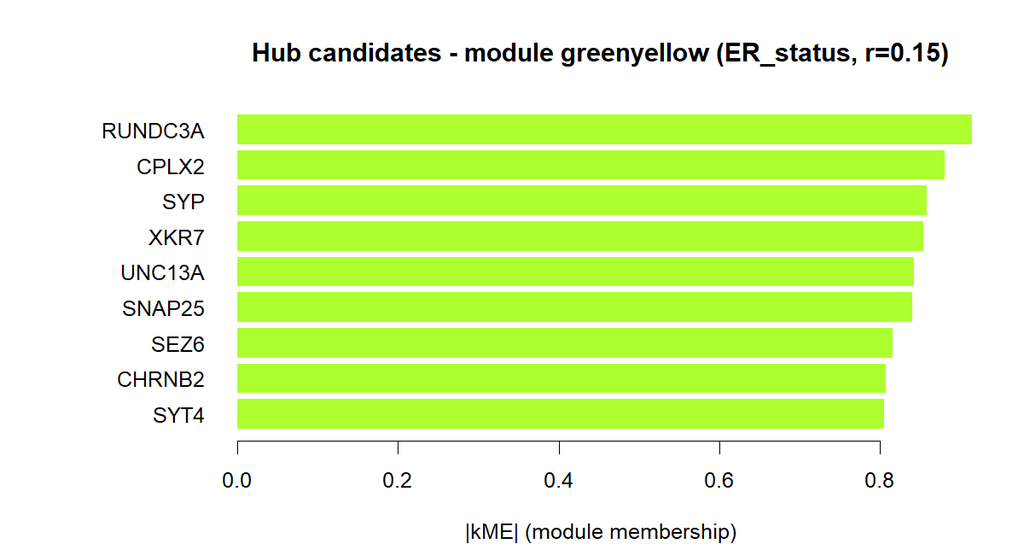

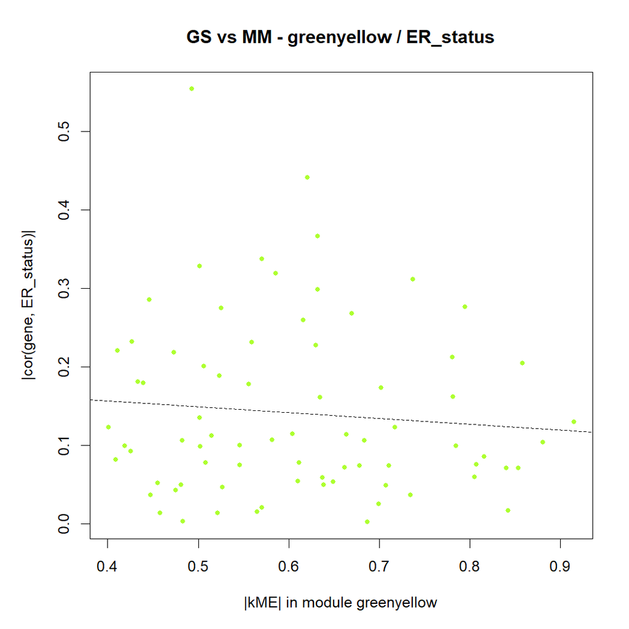

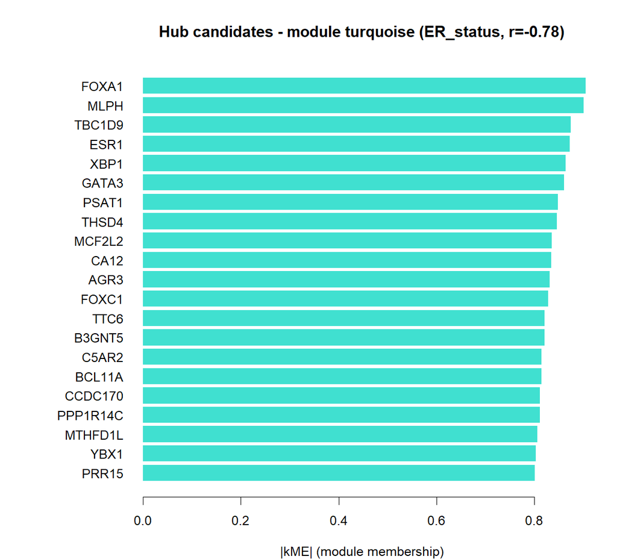

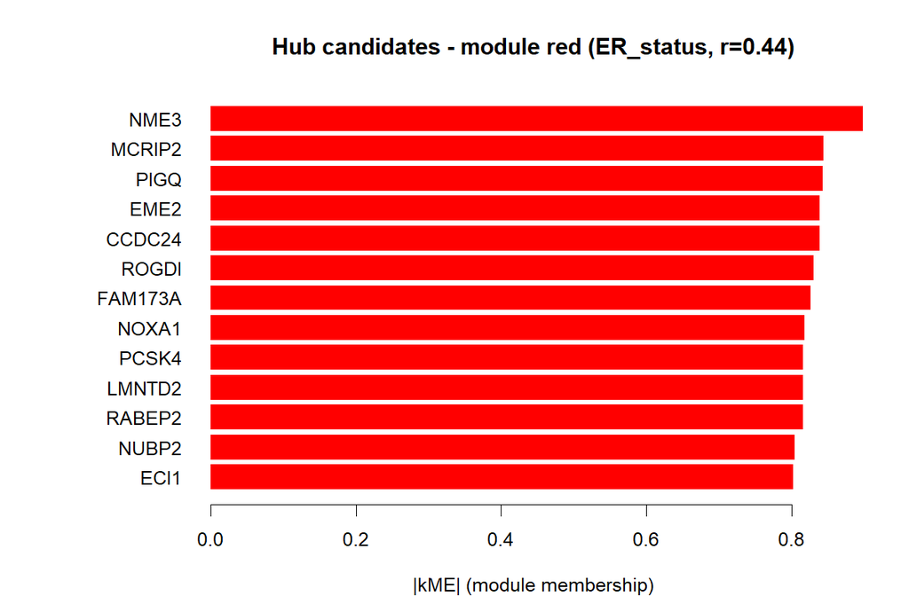

# 8 Output Files

The key machine-readable outputs are kept in `results/tables`, and the figures are kept in `results/figures`.

| Output | Path | Status |
| --- | --- | --- |
| DE results | results/tables/de_results.tsv | found |
| GO enrichment | results/tables/enrichment_go.tsv | found |
| KEGG enrichment | results/tables/enrichment_kegg.tsv | found |
| GO GSEA | results/tables/gsea_go.tsv | found |
| KEGG GSEA | results/tables/gsea_kegg.tsv | found |
| Module assignments | results/tables/module_assignments.tsv | found |
| Module annotation summary | results/tables/module_annotation_summary.tsv | found |
| Module preservation | results/tables/module_preservation.tsv | found |
| Ranked hubs | results/tables/hub_genes_ranked.tsv | found |
| Priority hubs | results/tables/hub_genes_priority_modules.tsv | found |